# Analysis of Domestic Flight Delays

## by Manuel Mane

## Investigation Overview

In this investigation, I wanted to look and find insights about the relationship of the different delays that airlines have experienced according their carrier, time of the year, airport in order to predict future delays. The main focus my investigation is centralized are in the variables that describe the different delays, such as delay by weather condition, by late aircraft, security and NAS (National Air System) issues and their impact in the different airlines in the different times of the year.

## Dataset Overview

The data consisted on the sum of minutes in flight delays by carrier and airport, tracked at the end of each month since June 2003 to July 2020. There were a total of 285159 observations and 22 variables in the data.

## Distribution Arrival Delays in Minutes

Arr_time variable which describes the difference in minutes between scheduled and actual arrival time has a right skewed distribution because of the high amountof delayed flights being 0 and 1000 minutes. Meanwhile the delay time increases, the amount of flights delayed with such amount is less. When applying the logarithmic scale, the distributions tends to be similar to a normal unimodal distribution with some small almost undetectable peaks. This behavior is similar among all of the distributions of the delay variables.

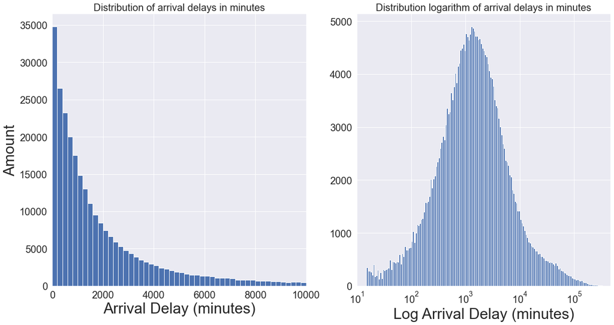

```python
import matplotlib
matplotlib.rc('xtick', labelsize=20)
matplotlib.rc('ytick', labelsize=20)

plt.figure(figsize=(20,10))

plt.subplot(1,2,1)
bins = np.arange(0, max(data.arr_delay), 200)
plt.hist(data.arr_delay, bins = bins, color=sb.color_palette()[0])
plt.title("Distribution of arrival delays in minutes", size=20)
plt.xlabel("Arrival Delay (minutes)", size=30)
plt.ylabel("Amount", size=30)
plt.xlim(0,10000)



plt.subplot(1,2,2)
binsize=0.025
log_bins = 10**np.arange(0.025, np.log10(max(data.arr_delay))+binsize, binsize)
plt.hist(data.arr_delay, bins = log_bins, color=sb.color_palette()[0])
plt.xlim(xmin=10)
plt.xscale('log')
plt.title("Distribution logarithm of arrival delays in minutes", size=20)
plt.xlabel("Log Arrival Delay (minutes)", size=30);
```

## Correlation of the delays and arrivals

In this plot we can observe the correlation among the cancelled flights (arr_flights), the diverted flights (arr_diverted), the amount of arrived flights (arr_flights) and the amount of arrival delays (arr_delays).

As anyone could expect, there is a positive correlation between the number of flights, the delayed flights, and the cancelled flights, meaning that when more flights arrived there were a higher probablibity of experiencing delays and cancelations.

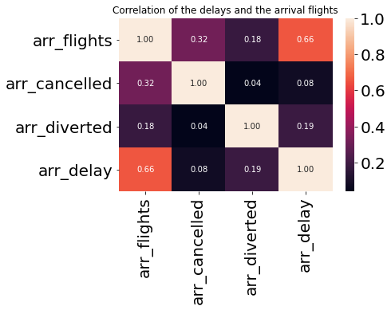

```python
data_df = data[data.arr_delay < 5000]
sb.heatmap(data_df[['arr_flights', 'arr_cancelled', 'arr_diverted', 'arr_delay']].corr(), annot=True, fmt = '.2f')
plt.title("Correlation of the delays and the arrival flights");
```

## Top 10 Airlines

There are the airlines with more flights in the dataset

`OO`: SkyWest Airlines Inc.

`EV`: Atlantic Southeast Airlines

`DL`: Delta Air Lines Inc

`MQ`: American Eagle Airlines Inc.

`AA`: American Airlines

`UA`: United Air Lines Inc.

`YV`: Mesa Airlines Inc.

`AS`: Alaska Airlines Inc.

`US`: US Airways Inc.

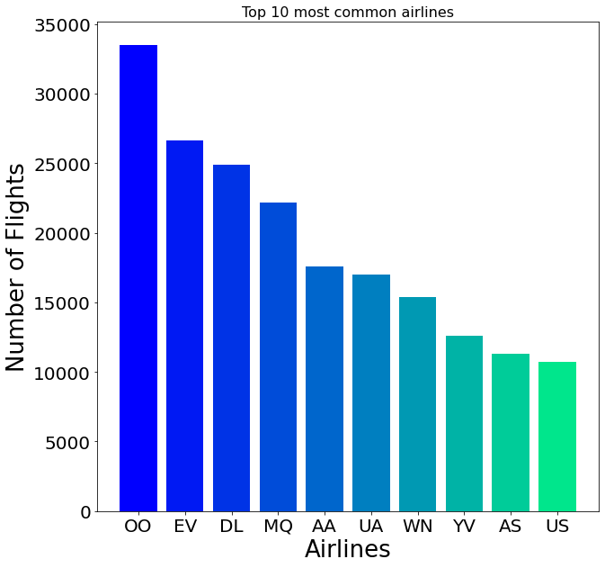

```python
import matplotlib.cm as cm
from matplotlib.colors import Normalize
my_cmap = cm.get_cmap('winter_r')
values = [20,18,16,14,12,10,8,6,4,2,0]
plt.figure(figsize=(10,10))
my_norm = Normalize(vmin=0, vmax=20)

plt.bar(x=data.carrier.value_counts()[:10].index, height=data.carrier.value_counts()[:10], color=my_cmap(my_norm(values)) )
plt.title("Top 10 most common airlines", size=16)
plt.xlabel("Airlines", size=26)
plt.ylabel("Number of Flights", size=26);
```

## Top Airlines vs Aircraft related delay by Month

In this graph I compared the delay by late artefact parameter of the airlines by month. Thanks to the color label we can notice how the most common airliness do not neccessarily are the ones that experience more delays.

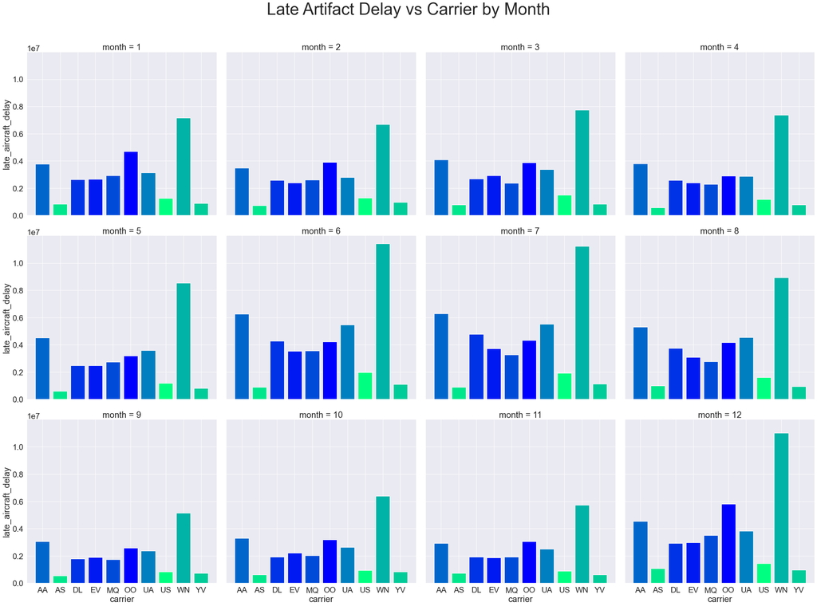

```python
# Top 10 airlines with more delays
top_10_most_common_airlines = data.carrier.value_counts()[:10].index


# Data with the most common airlines
top_airlines = data.query("carrier in @top_10_most_common_airlines")

top_airlines = top_airlines.groupby(['month', 'carrier']).sum()[['arr_delay','carrier_delay','weather_delay', 'nas_delay','security_delay','late_aircraft_delay']]
top_airlines = top_airlines.reset_index()

sb.set(font_scale=2)

values = [12,2,16,18,14,20,10,0,6,4]
g = sb.FacetGrid(data=top_airlines, col='month', col_wrap = 4, size=8)
g.map(plt.bar, 'carrier', 'late_aircraft_delay', color = my_cmap(my_norm(values)))
plt.subplots_adjust(top=0.9)
g.fig.suptitle("Late Artifact Delay vs Carrier by Month", size=46);
```

## Arrival Delays by top Airports

In this plot I describe the amount of delays in the top 5 busiest airports. I take into consideration the top 10 airlines as these one have the most representation in the data.

**Top 5 Airports** `DCA`: Washington, DC: Ronald Reagan Washington National `DTW`: Detroit, MI: Detroit Metro Wayne County `LAS`: Las Vegas, NV: McCarran International  
`MCI`: Kansas City, MO: Kansas City International  
`LAX`: Los Angeles, CA: Los Angeles Internationa

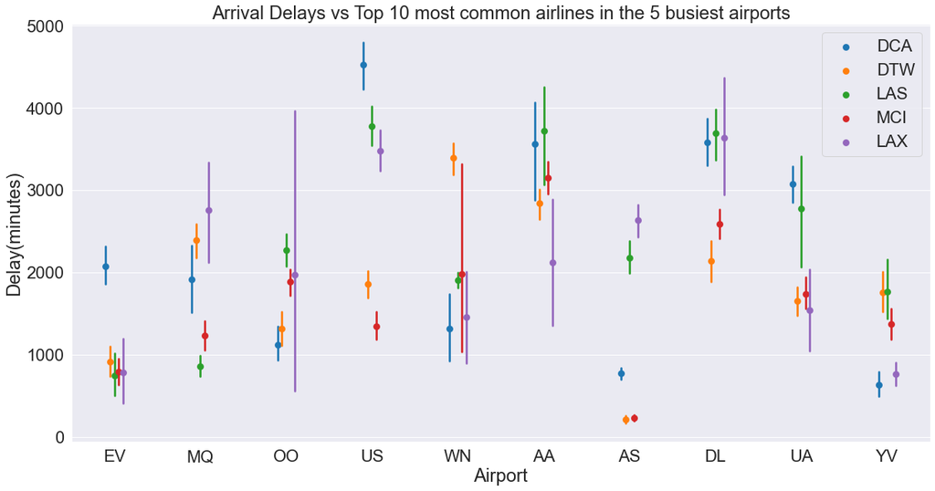

```python
top_5_airports = data.airport.value_counts()[:5].index
data_top = data_df.query("airport in @top_5_airports & carrier in @top_10_most_common_airlines")


plt.figure(figsize=(20,10))
sb.pointplot(data=data_top, x='carrier', y='arr_delay', hue='airport', dodge=0.2, linestyles="", palette='tab10')
plt.xlabel("Airport")
plt.ylabel("Delay(minutes)")
plt.title("Arrival Delays vs Top 10 most common airlines in the 5 busiest airports")
plt.legend();
```